# Cyclistic bike share analysis

Kirui Ian Mark

10/10/2021

# ASK

Business task: How do annual members and casual riders use Cyclistic bikes differently?

## Problem Statement

Cyclistic is faced with an uncertain future and is no longer able to solely rely on their traditional marketing strategies of raising general awareness and appealing to a variety of needs with flexible price points and diverse product choices. In the interest of company growth, the director of marketing believes that Cyclistic should capitalize on the lucrative profit margins of annual subscribers by marketing to existing casual customers and persuading them to become yearly subscribers. If that strategy is plausible, a successfully executed marketing campaign would result in more sustainable long-term revenue. To that end, we need to analyze how and why Cyclistic casual bikers and members differ to weigh any evidence, opportunities and barriers to any future conversion strategy.

# Prepare: collecting data and checking its constraints

### location of data:

The data we’ll be using was extracted from here with a helper dataset downloaded from here and is made available by Motivate International Inc. under this license. Note that Cyclistic is a fictional entity and Divvy’s open data is used for the purpose of this case study.

The data available to us consists of a repository made up of quantitative measurements collected over time. Each data point represents a single bike trip from one docking station to the next. On first glance, this data does not seem sufficient to fully comprehend how casuals and members use Cyclistic bikes differently. This data provides an overhead view of what they may be doing differently, but not the why. At this stage I would recommend putting the project on hold to collect more pertinent data. In particular, it would be useful to survey members and casuals on the ground to get answers to essential qualitative questions like “What do you use Cyclistic bikes for?” and “What discourages you from using Cyclistic bikes?”.

Assuming that executives are unwilling to commit additional resources and time to collect more data, we will do our best with the data currently on hand.

### Data quality assessment:

Reliable: ⚠️

The data is sourced by a first-party group (Motivate International Inc.) using their own resources without any third-party intervention

Comprehensiveness: ✅

This data set is comprehensive enough for our inquiry, and is mostly free of human error

Current: ✅

The time frame we’re examining gives us an up to date view

Vetted: ✅

On initial investigation, most records are free of errors and represent factual bike trips in Chicago

### purpose of the data uploaded

This dataset will assist in finding trends and insights that outlines how Cyclistic bikes are being used by different user types

### Assumptions

It is assumed that the data collection process was accomplished with integrity. The accuracy, bias, and credibility is sufficiently vetted by the first-hand source of the data. The original repository has never been accessed or modified in any unauthorized manner.

### Tools of choice

The tools of choice was R-Studio. It has faster and easier manipulation of data as compared to spreadsheets for the case of this dataset which is quite big .

# Processing data for analysis

## Setting up my environment

Notes: setting up my R environment by loading relevant packages used for cleaning data, analyzing and visualization

collecting and uploading data for cleaning and analysis

```
## [1] "D:/google data analytics course/Cyclistic Bike Share"
```

Notes: checking the column names of data uploaded

```
##  [1] "ride_id"            "rideable_type"      "started_at"
##  [4] "ended_at"           "start_station_name" "start_station_id"
##  [7] "end_station_name"   "end_station_id"     "start_lat"
## [10] "start_lng"          "end_lat"            "end_lng"
## [13] "member_casual"
```

```
##  [1] "ride_id"            "rideable_type"      "started_at"
##  [4] "ended_at"           "start_station_name" "start_station_id"
##  [7] "end_station_name"   "end_station_id"     "start_lat"
## [10] "start_lng"          "end_lat"            "end_lng"
## [13] "member_casual"
```

```
##  [1] "ride_id"            "rideable_type"      "started_at"
##  [4] "ended_at"           "start_station_name" "start_station_id"
##  [7] "end_station_name"   "end_station_id"     "start_lat"
## [10] "start_lng"          "end_lat"            "end_lng"
## [13] "member_casual"
```

```
##  [1] "ride_id"            "rideable_type"      "started_at"
##  [4] "ended_at"           "start_station_name" "start_station_id"
##  [7] "end_station_name"   "end_station_id"     "start_lat"
## [10] "start_lng"          "end_lat"            "end_lng"
## [13] "member_casual"
```

```
##  [1] "ride_id"            "rideable_type"      "started_at"
##  [4] "ended_at"           "start_station_name" "start_station_id"
##  [7] "end_station_name"   "end_station_id"     "start_lat"
## [10] "start_lng"          "end_lat"            "end_lng"
## [13] "member_casual"
```

```
##  [1] "ride_id"            "rideable_type"      "started_at"
##  [4] "ended_at"           "start_station_name" "start_station_id"
##  [7] "end_station_name"   "end_station_id"     "start_lat"
## [10] "start_lng"          "end_lat"            "end_lng"
## [13] "member_casual"
```

```
##  [1] "ride_id"            "rideable_type"      "started_at"
##  [4] "ended_at"           "start_station_name" "start_station_id"
##  [7] "end_station_name"   "end_station_id"     "start_lat"
## [10] "start_lng"          "end_lat"            "end_lng"
## [13] "member_casual"
```

```
##  [1] "ride_id"            "rideable_type"      "started_at"
##  [4] "ended_at"           "start_station_name" "start_station_id"
##  [7] "end_station_name"   "end_station_id"     "start_lat"
## [10] "start_lng"          "end_lat"            "end_lng"
## [13] "member_casual"
```

```
##  [1] "ride_id"            "rideable_type"      "started_at"
##  [4] "ended_at"           "start_station_name" "start_station_id"
##  [7] "end_station_name"   "end_station_id"     "start_lat"
## [10] "start_lng"          "end_lat"            "end_lng"
## [13] "member_casual"
```

```
##  [1] "ride_id"            "rideable_type"      "started_at"
##  [4] "ended_at"           "start_station_name" "start_station_id"
##  [7] "end_station_name"   "end_station_id"     "start_lat"
## [10] "start_lng"          "end_lat"            "end_lng"
## [13] "member_casual"
```

```
##  [1] "ride_id"            "rideable_type"      "started_at"
##  [4] "ended_at"           "start_station_name" "start_station_id"
##  [7] "end_station_name"   "end_station_id"     "start_lat"
## [10] "start_lng"          "end_lat"            "end_lng"
## [13] "member_casual"
```

```
##  [1] "ride_id"            "rideable_type"      "started_at"
##  [4] "ended_at"           "start_station_name" "start_station_id"
##  [7] "end_station_name"   "end_station_id"     "start_lat"
## [10] "start_lng"          "end_lat"            "end_lng"
## [13] "member_casual"
```

Notes: since we are investigating how different riders use the cylcistic bikes differently it will require to make some calculation in time, so the need to change the default datatype of the started_at and ended_at columns

Notes: combining the dataset into one single csv file and assigning it to a dataframe

```r
bike_df <- rbind(oct_2020,nov_2020,dec_2020,jan_2021,feb_2021,
                 mar_2021,apr_2021,may_2021,jun_2021,jul_2021,aug_2021,
                 sep_2021)
```

Notes: a look at the dataframe

```r
glimpse(bike_df)
```

```
## Rows: 5,136,261
## Columns: 13
## $ ride_id            <chr> "ACB6B40CF5B9044C", "DF450C72FD109C01", "B6396B54A1~
## $ rideable_type      <chr> "electric_bike", "electric_bike", "electric_bike", ~
## $ started_at         <dttm> 2020-10-31 19:39:43, 2020-10-31 23:50:08, 2020-10-~
## $ ended_at           <dttm> 2020-10-31 19:57:12, 2020-11-01 00:04:16, 2020-10-~
## $ start_station_name <chr> "Lakeview Ave & Fullerton Pkwy", "Southport Ave & W~
## $ start_station_id   <chr> "313", "227", "102", "165", "190", "359", "313", "1~
## $ end_station_name   <chr> "Rush St & Hubbard St", "Kedzie Ave & Milwaukee Ave~
## $ end_station_id     <chr> "125", "260", "423", "256", "185", "53", "125", "31~
## $ start_lat          <dbl> 41.92610, 41.94817, 41.77346, 41.95085, 41.92886, 4~
## $ start_lng          <dbl> -87.63898, -87.66391, -87.58537, -87.65924, -87.663~
## $ end_lat            <dbl> 41.89035, 41.92953, 41.79145, 41.95281, 41.91778, 4~
## $ end_lng            <dbl> -87.62607, -87.70782, -87.60005, -87.65010, -87.691~
## $ member_casual      <chr> "casual", "casual", "casual", "casual", "casual", "~
```

checking for any null/NA values and omitting them

```r
bike_df_1 <- bike_df[complete.cases(bike_df), ]

bike_df_1  <- na.omit(bike_df)
```

```r
str(bike_df_1)
```

```
## tibble [4,270,549 x 13] (S3: tbl_df/tbl/data.frame)
##  $ ride_id           : chr [1:4270549] "ACB6B40CF5B9044C" "DF450C72FD109C01" "B6396B54A15AC0DF" "44A4AEE261B9E854" ...
##  $ rideable_type     : chr [1:4270549] "electric_bike" "electric_bike" "electric_bike" "electric_bike" ...
##  $ started_at        : POSIXct[1:4270549], format: "2020-10-31 19:39:43" "2020-10-31 23:50:08" ...
##  $ ended_at          : POSIXct[1:4270549], format: "2020-10-31 19:57:12" "2020-11-01 00:04:16" ...
##  $ start_station_name: chr [1:4270549] "Lakeview Ave & Fullerton Pkwy" "Southport Ave & Waveland Ave" "Stony Island Ave & 67th St" "Clark St & Grace St" ...
##  $ start_station_id  : chr [1:4270549] "313" "227" "102" "165" ...
##  $ end_station_name  : chr [1:4270549] "Rush St & Hubbard St" "Kedzie Ave & Milwaukee Ave" "University Ave & 57th St" "Broadway & Sheridan Rd" ...
##  $ end_station_id    : chr [1:4270549] "125" "260" "423" "256" ...
##  $ start_lat         : num [1:4270549] 41.9 41.9 41.8 42 41.9 ...
##  $ start_lng         : num [1:4270549] -87.6 -87.7 -87.6 -87.7 -87.7 ...
##  $ end_lat           : num [1:4270549] 41.9 41.9 41.8 42 41.9 ...
##  $ end_lng           : num [1:4270549] -87.6 -87.7 -87.6 -87.7 -87.7 ...
##  $ member_casual     : chr [1:4270549] "casual" "casual" "casual" "casual" ...
##  - attr(*, "na.action")= 'omit' Named int [1:865712] 9 15 17 31 33 34 35 36 42 45 ...
##   ..- attr(*, "names")= chr [1:865712] "9" "15" "17" "31" ...
```

renaming columns

```r
bike_df_1 <- bike_df_1 %>% rename(trip_id = ride_id, ride_type = rideable_type, start_time = started_at, end_time= ended_at)
glimpse(bike_df)
```

```
## Rows: 5,136,261
## Columns: 13
## $ ride_id            <chr> "ACB6B40CF5B9044C", "DF450C72FD109C01", "B6396B54A1~
## $ rideable_type      <chr> "electric_bike", "electric_bike", "electric_bike", ~
## $ started_at         <dttm> 2020-10-31 19:39:43, 2020-10-31 23:50:08, 2020-10-~
## $ ended_at           <dttm> 2020-10-31 19:57:12, 2020-11-01 00:04:16, 2020-10-~
## $ start_station_name <chr> "Lakeview Ave & Fullerton Pkwy", "Southport Ave & W~
## $ start_station_id   <chr> "313", "227", "102", "165", "190", "359", "313", "1~
## $ end_station_name   <chr> "Rush St & Hubbard St", "Kedzie Ave & Milwaukee Ave~
## $ end_station_id     <chr> "125", "260", "423", "256", "185", "53", "125", "31~
## $ start_lat          <dbl> 41.92610, 41.94817, 41.77346, 41.95085, 41.92886, 4~
## $ start_lng          <dbl> -87.63898, -87.66391, -87.58537, -87.65924, -87.663~
## $ end_lat            <dbl> 41.89035, 41.92953, 41.79145, 41.95281, 41.91778, 4~
## $ end_lng            <dbl> -87.62607, -87.70782, -87.60005, -87.65010, -87.691~
## $ member_casual      <chr> "casual", "casual", "casual", "casual", "casual", "~
```

removing columns that are out of our scope

```r
bike_df_1 <- subset(bike_df_1, select = -c(start_lat:end_lng))
glimpse(bike_df_1)
```

```
## Rows: 4,270,549
## Columns: 9
## $ trip_id            <chr> "ACB6B40CF5B9044C", "DF450C72FD109C01", "B6396B54A1~
## $ ride_type          <chr> "electric_bike", "electric_bike", "electric_bike", ~
## $ start_time         <dttm> 2020-10-31 19:39:43, 2020-10-31 23:50:08, 2020-10-~
## $ end_time           <dttm> 2020-10-31 19:57:12, 2020-11-01 00:04:16, 2020-10-~
## $ start_station_name <chr> "Lakeview Ave & Fullerton Pkwy", "Southport Ave & W~
## $ start_station_id   <chr> "313", "227", "102", "165", "190", "359", "313", "1~
## $ end_station_name   <chr> "Rush St & Hubbard St", "Kedzie Ave & Milwaukee Ave~
## $ end_station_id     <chr> "125", "260", "423", "256", "185", "53", "125", "31~
## $ member_casual      <chr> "casual", "casual", "casual", "casual", "casual", "~
```

```r
bike_df_1 <- bike_df_1%>% distinct()

str(bike_df_1)
```

```
## tibble [4,270,549 x 9] (S3: tbl_df/tbl/data.frame)
##  $ trip_id           : chr [1:4270549] "ACB6B40CF5B9044C" "DF450C72FD109C01" "B6396B54A15AC0DF" "44A4AEE261B9E854" ...
##  $ ride_type         : chr [1:4270549] "electric_bike" "electric_bike" "electric_bike" "electric_bike" ...
##  $ start_time        : POSIXct[1:4270549], format: "2020-10-31 19:39:43" "2020-10-31 23:50:08" ...
##  $ end_time          : POSIXct[1:4270549], format: "2020-10-31 19:57:12" "2020-11-01 00:04:16" ...
##  $ start_station_name: chr [1:4270549] "Lakeview Ave & Fullerton Pkwy" "Southport Ave & Waveland Ave" "Stony Island Ave & 67th St" "Clark St & Grace St" ...
##  $ start_station_id  : chr [1:4270549] "313" "227" "102" "165" ...
##  $ end_station_name  : chr [1:4270549] "Rush St & Hubbard St" "Kedzie Ave & Milwaukee Ave" "University Ave & 57th St" "Broadway & Sheridan Rd" ...
##  $ end_station_id    : chr [1:4270549] "125" "260" "423" "256" ...
##  $ member_casual     : chr [1:4270549] "casual" "casual" "casual" "casual" ...
##  - attr(*, "na.action")= 'omit' Named int [1:865712] 9 15 17 31 33 34 35 36 42 45 ...
##   ..- attr(*, "names")= chr [1:865712] "9" "15" "17" "31" ...
```

prior calculations that are necessary for analysis phase

```r
bike_df_1$ride_length <- as.double(bike_df_1$end_time- bike_df_1$start_time)/60
str(bike_df_1)
```

```
## tibble [4,270,549 x 10] (S3: tbl_df/tbl/data.frame)
##  $ trip_id           : chr [1:4270549] "ACB6B40CF5B9044C" "DF450C72FD109C01" "B6396B54A15AC0DF" "44A4AEE261B9E854" ...
##  $ ride_type         : chr [1:4270549] "electric_bike" "electric_bike" "electric_bike" "electric_bike" ...
##  $ start_time        : POSIXct[1:4270549], format: "2020-10-31 19:39:43" "2020-10-31 23:50:08" ...
##  $ end_time          : POSIXct[1:4270549], format: "2020-10-31 19:57:12" "2020-11-01 00:04:16" ...
##  $ start_station_name: chr [1:4270549] "Lakeview Ave & Fullerton Pkwy" "Southport Ave & Waveland Ave" "Stony Island Ave & 67th St" "Clark St & Grace St" ...
##  $ start_station_id  : chr [1:4270549] "313" "227" "102" "165" ...
##  $ end_station_name  : chr [1:4270549] "Rush St & Hubbard St" "Kedzie Ave & Milwaukee Ave" "University Ave & 57th St" "Broadway & Sheridan Rd" ...
##  $ end_station_id    : chr [1:4270549] "125" "260" "423" "256" ...
##  $ member_casual     : chr [1:4270549] "casual" "casual" "casual" "casual" ...
##  $ ride_length       : num [1:4270549] 17.48 14.13 8.35 2.87 16.22 ...
##  - attr(*, "na.action")= 'omit' Named int [1:865712] 9 15 17 31 33 34 35 36 42 45 ...
##   ..- attr(*, "names")= chr [1:865712] "9" "15" "17" "31" ...
```

```r
summary(bike_df_1$ride_length)
```

```
##      Min.   1st Qu.    Median      Mean   3rd Qu.      Max.
## -29049.97      7.25     12.77     20.68     23.12  55944.15
```

```r
bike_df_1$day_of_week <- weekdays(bike_df_1$start_time)
bike_df_1$month <- months(bike_df_1$start_time)
bike_df_1$time <- hour(bike_df_1$start_time)
str(bike_df_1)
```

```
## tibble [4,270,549 x 13] (S3: tbl_df/tbl/data.frame)
##  $ trip_id           : chr [1:4270549] "ACB6B40CF5B9044C" "DF450C72FD109C01" "B6396B54A15AC0DF" "44A4AEE261B9E854" ...
##  $ ride_type         : chr [1:4270549] "electric_bike" "electric_bike" "electric_bike" "electric_bike" ...
##  $ start_time        : POSIXct[1:4270549], format: "2020-10-31 19:39:43" "2020-10-31 23:50:08" ...
##  $ end_time          : POSIXct[1:4270549], format: "2020-10-31 19:57:12" "2020-11-01 00:04:16" ...
##  $ start_station_name: chr [1:4270549] "Lakeview Ave & Fullerton Pkwy" "Southport Ave & Waveland Ave" "Stony Island Ave & 67th St" "Clark St & Grace St" ...
##  $ start_station_id  : chr [1:4270549] "313" "227" "102" "165" ...
##  $ end_station_name  : chr [1:4270549] "Rush St & Hubbard St" "Kedzie Ave & Milwaukee Ave" "University Ave & 57th St" "Broadway & Sheridan Rd" ...
##  $ end_station_id    : chr [1:4270549] "125" "260" "423" "256" ...
##  $ member_casual     : chr [1:4270549] "casual" "casual" "casual" "casual" ...
##  $ ride_length       : num [1:4270549] 17.48 14.13 8.35 2.87 16.22 ...
##  $ day_of_week       : chr [1:4270549] "Saturday" "Saturday" "Saturday" "Saturday" ...
##  $ month             : chr [1:4270549] "October" "October" "October" "October" ...
##  $ time              : int [1:4270549] 19 23 23 22 19 17 9 16 16 21 ...
##  - attr(*, "na.action")= 'omit' Named int [1:865712] 9 15 17 31 33 34 35 36 42 45 ...
##   ..- attr(*, "names")= chr [1:865712] "9" "15" "17" "31" ...
```

```r
bike_df_1 <- subset(bike_df_1, -ride_length<0)
str(bike_df_1)
```

```
## tibble [4,267,224 x 13] (S3: tbl_df/tbl/data.frame)
##  $ trip_id           : chr [1:4267224] "ACB6B40CF5B9044C" "DF450C72FD109C01" "B6396B54A15AC0DF" "44A4AEE261B9E854" ...
##  $ ride_type         : chr [1:4267224] "electric_bike" "electric_bike" "electric_bike" "electric_bike" ...
##  $ start_time        : POSIXct[1:4267224], format: "2020-10-31 19:39:43" "2020-10-31 23:50:08" ...
##  $ end_time          : POSIXct[1:4267224], format: "2020-10-31 19:57:12" "2020-11-01 00:04:16" ...
##  $ start_station_name: chr [1:4267224] "Lakeview Ave & Fullerton Pkwy" "Southport Ave & Waveland Ave" "Stony Island Ave & 67th St" "Clark St & Grace St" ...
##  $ start_station_id  : chr [1:4267224] "313" "227" "102" "165" ...
##  $ end_station_name  : chr [1:4267224] "Rush St & Hubbard St" "Kedzie Ave & Milwaukee Ave" "University Ave & 57th St" "Broadway & Sheridan Rd" ...
##  $ end_station_id    : chr [1:4267224] "125" "260" "423" "256" ...
##  $ member_casual     : chr [1:4267224] "casual" "casual" "casual" "casual" ...
##  $ ride_length       : num [1:4267224] 17.48 14.13 8.35 2.87 16.22 ...
##  $ day_of_week       : chr [1:4267224] "Saturday" "Saturday" "Saturday" "Saturday" ...
##  $ month             : chr [1:4267224] "October" "October" "October" "October" ...
##  $ time              : int [1:4267224] 19 23 23 22 19 17 9 16 16 21 ...
##  - attr(*, "na.action")= 'omit' Named int [1:865712] 9 15 17 31 33 34 35 36 42 45 ...
##   ..- attr(*, "names")= chr [1:865712] "9" "15" "17" "31" ...
```

# Analysis

### the following calculation are made to facilitate analysis and solve the problem statement

1. total ride_length by group

```
## # A tibble: 2 x 2
##   member_casual total_time
##   <chr>              <dbl>
## 1 casual         65478008.
## 2 member         31869953.
```

```
##     Min.  1st Qu.   Median     Mean  3rd Qu.     Max.
##     0.02     7.27    12.78    22.81    23.13 55944.15
```

2. summary of ride length for each group

```
## # A tibble: 2 x 5
##   member_casual min_ride_length max_ride_length mean_ride_length
##   <chr>                   <dbl>           <dbl>            <dbl>
## 1 casual                 0.0167          55944.             33.6
## 2 member                 0.0167           9558.             13.7
## # ... with 1 more variable: median_ride_length <dbl>
```

3. no of rides in each day of the week

```
## # A tibble: 14 x 3
## # Groups:   member_casual [2]
##    member_casual day_of_week num_of_rides
##    <chr>         <chr>              <int>
##  1 casual        Friday            276502
##  2 casual        Monday            217438
##  3 casual        Saturday          446000
##  4 casual        Sunday            379454
##  5 casual        Thursday          220681
##  6 casual        Tuesday           202128
##  7 casual        Wednesday         206916
##  8 member        Friday            334873
##  9 member        Monday            314295
## 10 member        Saturday          331317
## 11 member        Sunday            287943
## 12 member        Thursday          351496
## 13 member        Tuesday           342018
## 14 member        Wednesday         356163
```

4. no of rides per month and no of rides per ride type for each group

```r
bike_df_1 %>%  group_by(member_casual, month) %>%  summarize(num_of_rides= n())
```

```
## # A tibble: 22 x 3
## # Groups:   member_casual [2]
##    member_casual month    num_of_rides
##    <chr>         <chr>           <int>
##  1 casual        April          120418
##  2 casual        August         341463
##  3 casual        December        24492
##  4 casual        February         8613
##  5 casual        July           369401
##  6 casual        June           304184
##  7 casual        March           75641
##  8 casual        May            216823
##  9 casual        November        72847
## 10 casual        October        122317
## # ... with 12 more rows
```

```r
bike_df_1 %>%  group_by(member_casual, ride_type) %>% summarize(num_of_rides = n())
```

```
## # A tibble: 6 x 3
## # Groups:   member_casual [2]
##   member_casual ride_type     num_of_rides
##   <chr>         <chr>                <int>
## 1 casual        classic_bike       1108032
## 2 casual        docked_bike         404700
## 3 casual        electric_bike       436387
## 4 member        classic_bike       1573739
## 5 member        docked_bike         267338
## 6 member        electric_bike       477028
```

# Visualizations

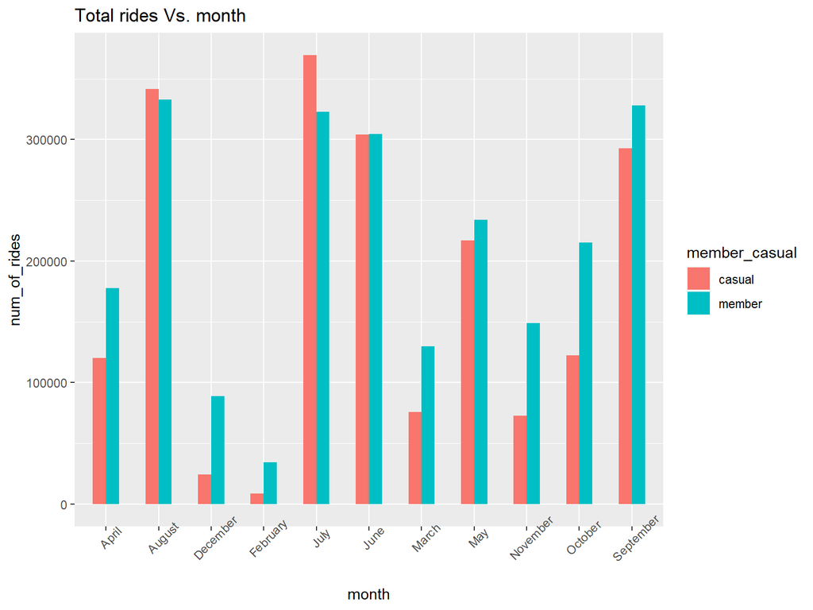

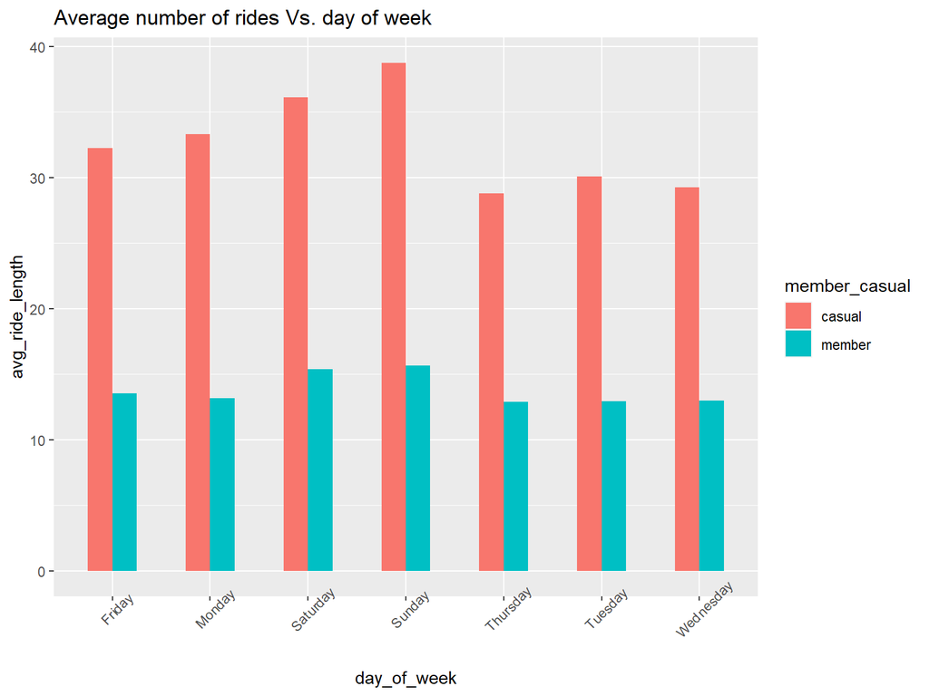

Throughout the week average ride length of casual riders is more than that of a member.On weekends the average ride length was the maximum from both the member types compared to weekdays.

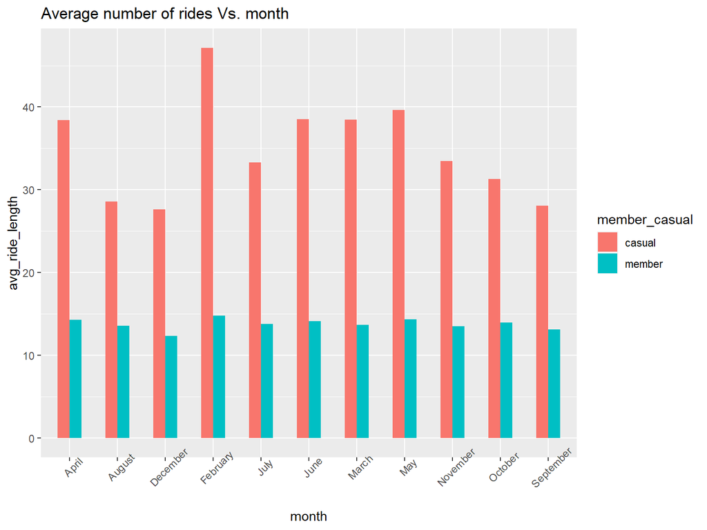

The average ride length by casual riders was more than membership riders throughout the year. It’s more than 30 minutes for most of the months by casual riders(except the months of august,december and september) and maximum in February accounting to 50 minutes. While membership riders average ride length never crossed 20 minutes.

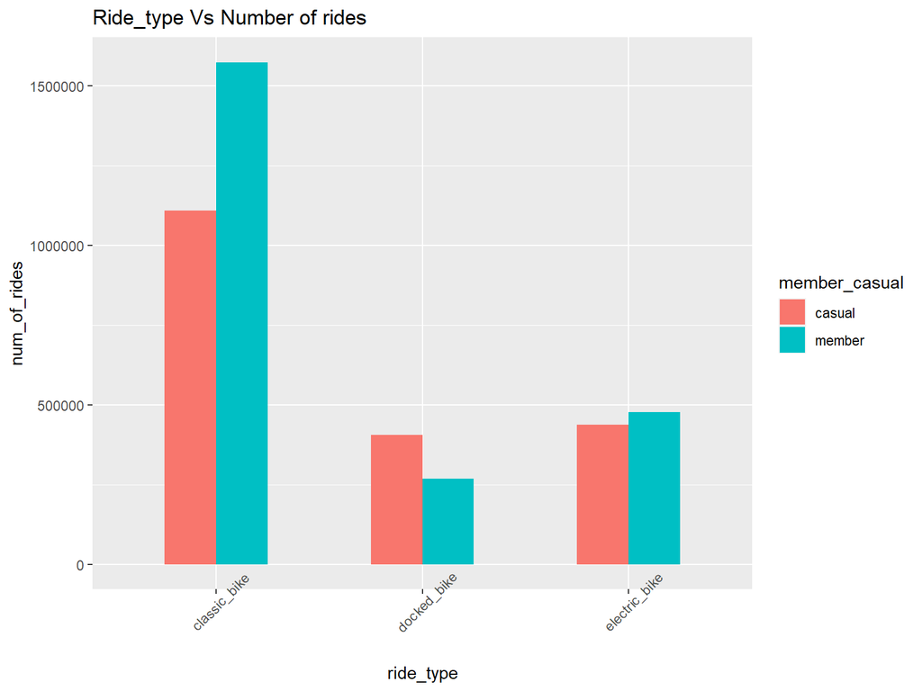

```r
bike_df_1 %>%
  group_by(ride_type, member_casual) %>%
  summarize(num_of_rides = n()) %>%
  ggplot(aes(x = ride_type, y = num_of_rides, fill= member_casual))+
  theme(axis.text.x = element_text(angle = 45))+
  geom_col(position = "dodge", width = 0.5)+
  labs(title ="Ride_type Vs Number of rides")+
  scale_y_continuous()
```

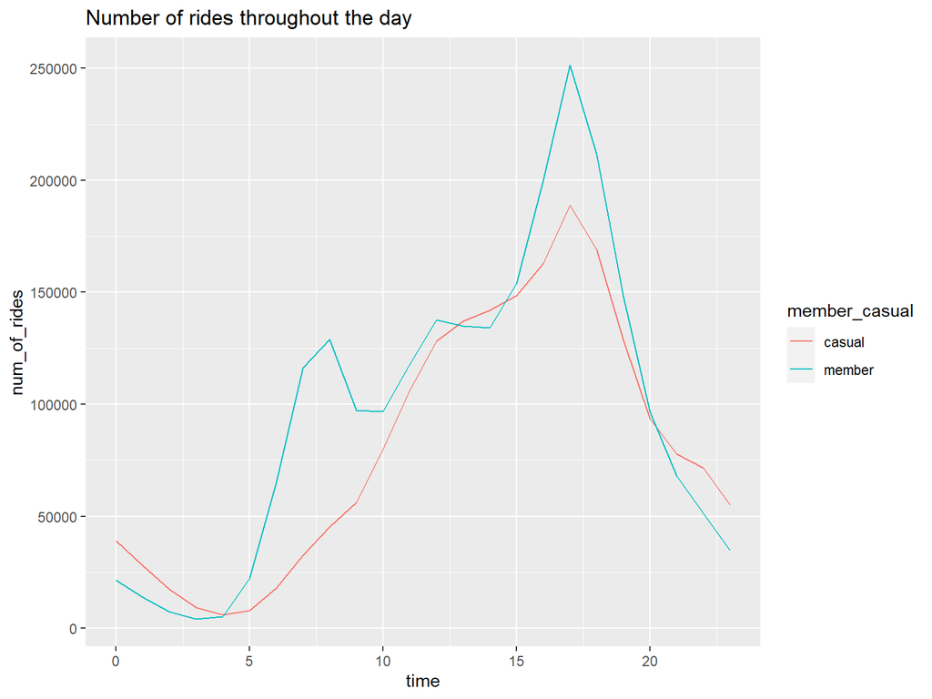

```r
bike_df_1 %>% group_by(member_casual, time) %>%
 summarize(num_of_rides = n()) %>%
 ggplot(aes(x= time, y = num_of_rides, color = member_casual))+
geom_line() + labs(title = "Number of rides throughout the day")
```

```r
scale_x_continuous()
```

```
## <ScaleContinuousPosition>
##  Range:
##  Limits:    0 --    1
```

The peak demand from both the types of riders was from 5 PM to 7 PM and the lowest was during the morning hours 2 AM to 4 AM. We can also see the seocnd peak from membership riders 7 AM to 9 AM.

## Takeaways:

$ Casual riders use the service more during weekends, while the demand from membership riders was same for the entire week.

$ Both casual and membership riders prefer the classical bikes.

## Recommendations:

$ Provide attractive packages during the weekdays to attract more casual riders, as their demand is very low in weekdays.

$ Neeed to provide memberships with some discount to ensure more casual riders take up the member